# ¶ DATA SCIENCE APLICADO A LA CIBERSEGURIDAD - Práctica 3 ¶

# PREGUNTA 1

Descomprimir el fichero comprimido que contiene los registros del servidor, y a partir de los datos extraídos, cargar en data frame los registros con las peticiones servidas.

```r
#Subimos el Documento
epa_http <- read_table("epa-http.csv", col_names = FALSE)

#Nombramos las columnas
nombres_columnas <- c("Origen", "Tiempo",  "Tipo" , "URL" , "Protocolo", "Código", "Bytes")
colnames(epa_http) <- nombres_columnas

#Realizamos la limpieza de los datos
epa_http$Tiempo <- gsub("\\[|\\]", "", epa_http$Tiempo)
epa_http$Tipo <- gsub("\"", "", epa_http$Tipo)
epa_http$Protocolo <- gsub("\"", "", epa_http$Protocolo)
epa_http$Bytes <- ifelse(is.na(as.numeric(epa_http$Bytes)), NA, as.numeric(epa_http$Bytes))
```

**Respuesta: Se realizó la limpieza de la data del fichero comprimido. Por motivo de performance no se muestra la tabla en el documento debido a la cantidad de filas que tiene, para mayor detalle de la tabla, revisar el documento “Práctica 3.R”**

# PREGUNTA 2

Identificar el número único de usuarios que han interactuado directamente con el servidor de forma segregada según si los usuarios han tenido algún tipo de error en las distintas peticiones ofrecidas por el servidor.

**Respuesta: Se interpreta de la siguiente manera:** **Si un usuario tiene el Código 200 significa que se han conectado al Servidor** **Si un usuario tiene el Código diferente a 200 significa que no se han podido conectar al Servidor por algún error** **Un usuario único puede haber tenido Conexión y haber estado Sin Conexión al servidor en tiempos diferente**

**Teniendo en cuenta lo antes mencionado, la respuesta es la siguiente**

```
## Cantidad de usuarios únicos que se conectaron al servidor existosamente: 2296
```

```
## Cantidad de usuarios únicos que no se conectaron al servidor por algún tipo de error: 1244
```

# PREGUNTA 3

Analizar los distintos tipos de peticiones HTTP (GET, POST, PUT, DELETE) gestionadas por el servidor, identificando la frecuencia de cada una de estas. Repetir el análisis, esta vez filtrando previamente aquellas peticiones correspondientes a recursos ofrecidos de tipo imagen.

**Respuesta: La frecuencia de los tipos de peticiones para recursos de tipo imagen son:**

```
##
##   GET  HEAD  POST
## 22189    56   206
```

# PREGUNTA 4

Generar un gráfico que permita visualizar las respuestas del servidor, es decir, la distribución de peticiones según el código de respuesta de esta. Probad distintos tipos de gráficos (por lo menos 2 distintos e incluid estos en el documento RMarkdown).

**Respuesta: Primer Gráfico - Barras:**

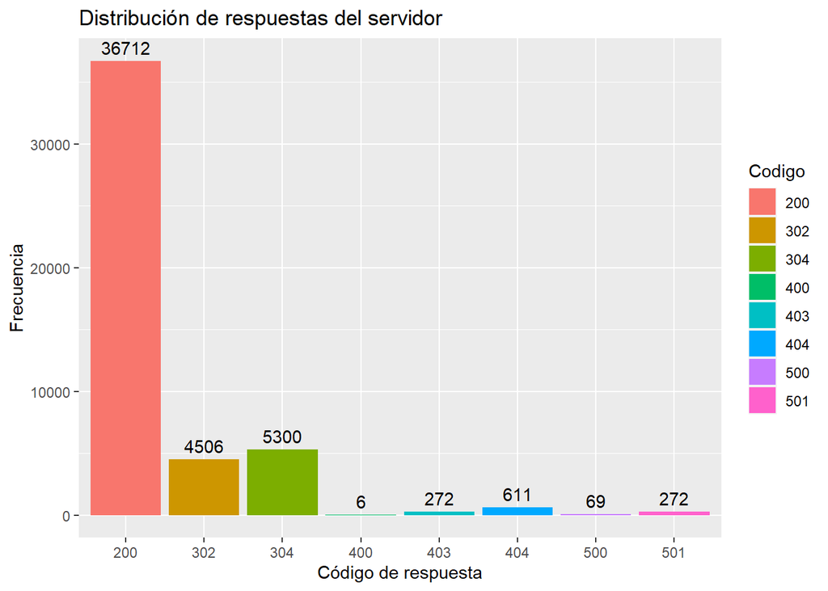

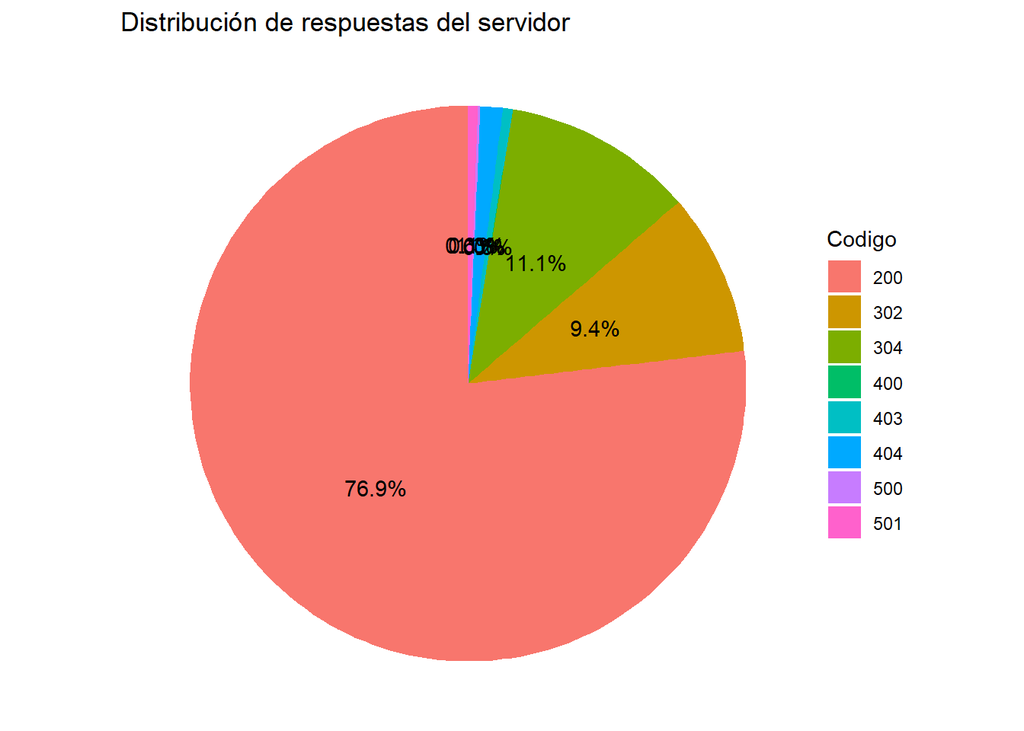

# PREGUNTA 5

Utilizando un algoritmo de aprendizaje no supervisado, realizad un análisis de clústering con k-means para los datos del servidor.

**Respuesta: Los clúster son:**

**Para K=3:**

```
## K-means clustering with 3 clusters of sizes 1316, 60, 46372
##
## Cluster means:
##   Caracteres_URL      Bytes
## 1      5.6974024  0.1229749
## 2      0.2160357 23.7419763
## 3     -0.1619672 -0.0342093
##
## Clustering vector:
##     [1] 3 3 3 3 3 3 3 3 3 3 3 3 3 3 3 3 3 3 3 3 3 3 3 3 3 3 3 3 3 3 3 3 3 3 3 3
##    [37] 3 3 3 1 3 3 3 3 3 3 3 3 3 3 3 3 3 3 3 3 3 3 3 3 3 3 3 3 3 3 3 3 3 3 3 3
##    [73] 3 3 3 3 3 3 3 3 3 3 3 3 3 3 3 3 3 3 3 3 3 3 3 3 3 3 3 1 3 3 3 3 3 3 3 3
##   [109] 3 3 3 1 3 3 1 3 3 3 3 3 3 3 3 3 3 3 3 3 3 3 3 3 3 3 3 3 3 3 3 3 3 3 3 3
##   [145] 3 3 3 3 3 3 3 3 3 3 3 3 3 1 3 3 3 3 3 3 3 3 3 3 3 3 3 3 3 1 3 3 3 3 1 3
##   [181] 3 3 3 3 3 3 3 3 3 3 3 3 3 3 3 3 3 3 3 3 3 3 3 3 3 3 3 3 3 3 3 3 3 3 3 3
```

[output cut: 1330 more lines]

**Para K=5:**

```
## K-means clustering with 5 clusters of sizes 1256, 60, 21161, 2068, 23203
##
## Cluster means:
##   Caracteres_URL       Bytes
## 1     5.82534351  0.13321108
## 2     0.21603568 23.74197626
## 3    -0.09768191 -0.05241945
## 4     0.61765513  0.65380622
## 5    -0.28185396 -0.07906973
##
## Clustering vector:
##     [1] 5 5 5 5 3 3 5 5 5 5 3 5 3 3 3 3 4 3 4 5 5 5 5 5 5 3 3 3 3 5 4 5 5 3 3 3
##    [37] 3 3 3 1 5 3 5 5 5 5 5 3 3 3 5 5 5 5 3 3 3 5 4 3 5 3 5 5 3 5 3 5 5 3 5 3
##    [73] 5 5 5 5 5 5 5 3 5 3 5 5 5 5 3 4 5 5 4 5 3 3 5 5 5 5 5 1 3 5 5 5 5 4 5 5
##   [109] 5 5 3 4 3 5 1 5 5 3 3 3 3 5 3 5 5 5 3 5 3 5 3 5 5 3 5 3 5 5 3 5 3 3 3 3
```

[output cut: 1332 more lines]

# PREGUNTA 6

Representad visualmente en gráficos de tipo scatter plot el resultado de vuestros clústering.

**Respuesta: Los Gráficos son los siguientes:**

**Para K=3:**

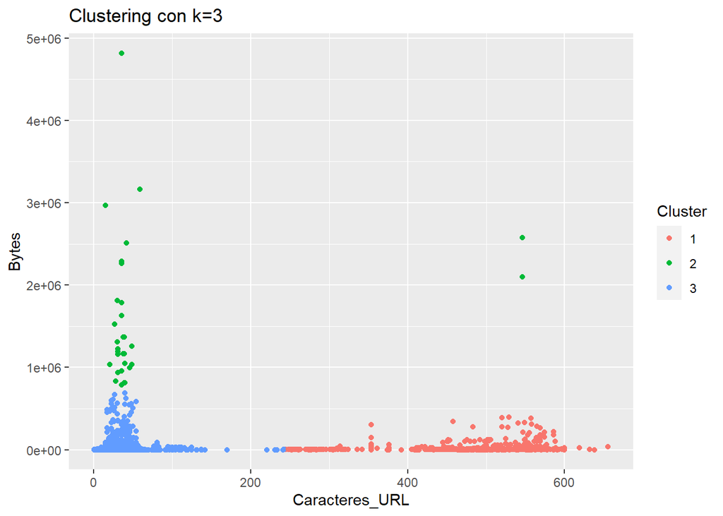

**Para K=5:**

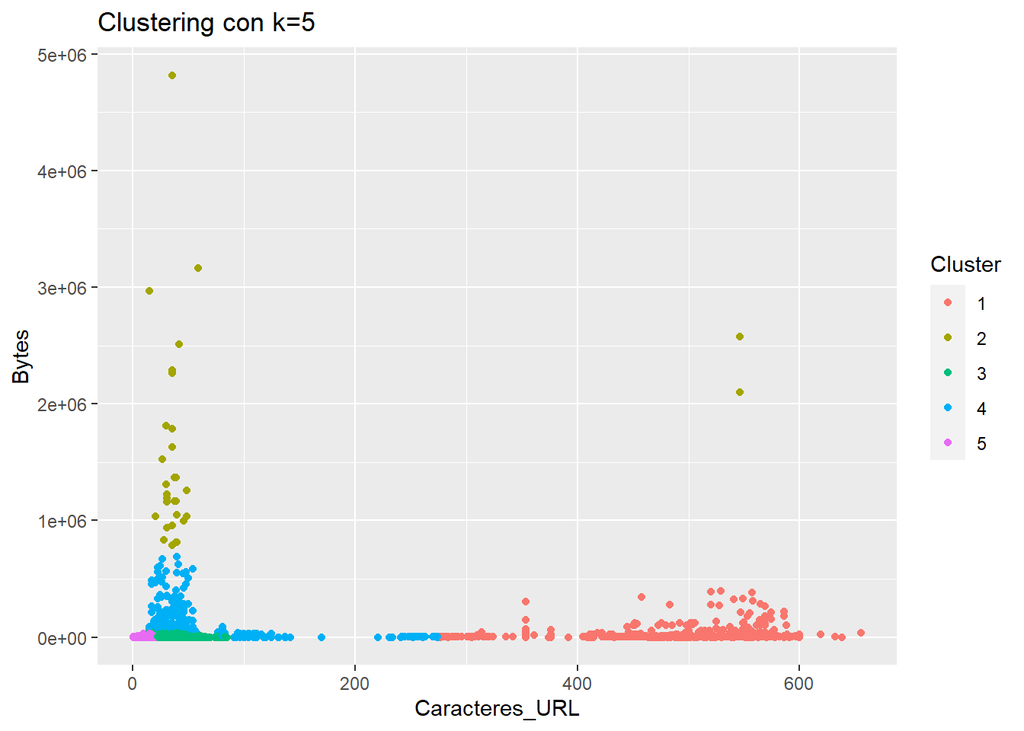